# DAG de producción lechera

Author

Selem Enrique Vazquez

## Transfiere DAG de Miro a R

En *Miro* se trabajaron varios posibles *DAG*, la lista de estos tableros se ilustra en la tabla Table 1.

Utilizando la biblioteca [miro2bayes](https://github.com/equihuam/miro2bayesNet). Convertiremos el modelo causal diseñado en [Miro](https://miro.com/) a **R**. A partir de esta operación será posible analizar formalmente el DAG. En **R** esto se puede hacer con las bibliotecas *dagitty* y *bnlearn*. Fuera de **R** se puede recurrir a [*Netica*](https://www.norsys.com/netica.html) y a [*Genie*](https://www.bayesfusion.com/), por ejemplo.

```r
tableros <- miroBoards(servMiro = "miro-leche", user = "miguel")

tableros |>
  flextable(col_keys = c("id", "name", "modifiedAt"))
```

Table 1: Lista de tableros “lecheros” en Miro

| id | name | modifiedAt |
| --- | --- | --- |
| uXjVKmAHyDk= | Lechería sustentable-4 | 2024-10-03T23:58:28Z |
| uXjVKNJcQ-0= | Copia de Lechería sustentable-3 | 2024-08-24T17:00:33Z |
| uXjVNDBiolg= | Copia de Lechería sustentable | 2024-01-08T21:54:37Z |
| uXjVN8QWtyg= | Copia de Lechería sustentable-2 | 2024-03-20T18:38:36Z |
| uXjVM9YKLd8= | Lechería sustentable | 2023-12-15T16:46:30Z |

De los modelos DAG elaborados, el que analizaremos y utilizaremos para hacer el análisis formal es Lechería sustentable-4

A continuación tenemos el reporte de *validación* del **DAG** diseñado en *Miro*.

```r
datos_leche <- getMiro(board = tableros$id[grepl("table-4", tableros$name)],
                       servMiro = "miro-leche",
                       user = "miguel")

miroValidation(datos_leche)
```

```
Miro board origin:      Miro: uXjVKmAHyDk=
Is it a TRUE DAG?:      Graph is acyclic
Number of sticky notes: 28
Nodes without var:      0
Number of linked nodes: 27
Duplicated nodes:       0
Number of arcs:         35
Well connected arcs:    35
Numb. Loose arcs:       0
Duplicated arcs:        0
```

El *DAG* contiene las siguientes variables

```r
variables <- tibble(var = datos_leche$nodes$var)
tibble(var = datos_leche$nodes$var, def = datos_leche$nodes$text) |>
  flextable()
```

| var | def |
| --- | --- |
| RENTABILIDAD T1 | EFICIENCIA ECONOMICA DEL SISTEMA(FUTURA) |
| LT_VIENTRE_TIEMPO | RENDIMIENTO DE LA UP |
| INDICE DE INDICADORES AMB_T0 | EFICIENCIA AMBIENTAL DEL SISTEMA(ACTUAL) |
| CAPITAL_T0 | CAPITALMONETARiODISPONIBLE(ACTUAL) |
| RENTABILIDAD_T0 | EFICIENCIA ECONÓMICA DEL SISTEMA(ACTUAL) |
| INDICE DE INDICADORES AMB_PREV | EFICIENCIA AMBIENTAL DEL SISTEMA(PREVIA) |
| M3_YEAR | AGUABalance de cuenca - uso |
| TCO2_EQUIV_TIEMPO | CARBONOBalance de stock - GEI |
| IND_INTEGR_ECO | CALIDAD DEL HABITAT |
| INDICE_POLITICA_PUBLICA | POLITICA PUBLICANivelesValor numérico de la encuesta.Dato continuo |
| INDICE_SOCIOAMBIENTAL | ACTITUD SOCIOAMBIENTAL |
| INDICE_DE_RELEVO | RELEVO GENERACIONAL(FUTURO) |
| EMPLEADOS_T1 | GENERACIÓNDE EMPLEO(ACTUAL) |
| EMPLEADOS_T0 | GENERACION DE EMPLEO(PREVIO) |
| VA_NETO | VALOR AGREGADO |
| CAPITAL_T1 | CAPITALMONETARiODISPONIBLE(FUTURO) |
| NUM DE GENERACIONES | RELEVO GENERACIONAL (ANTERIOR) |
| NIVEL_DE_ESTUDIOS | EDUCACIONÁREA/NIVEL1 Admon_L2 Admon_PG4 Biol_Agrop_L5 Biol_Agrop_PG No_carrera |
| INDICE SATISFACCION | SATISFACCION |
| INDICE_ASOCIATIVIDAD | ASOCIATIVIDAD |
| INDICE_BIENESTAR_ANIMAL | BIENESTAR ANIMAL |
| INDICE_ADMON_UP | ADMON DE LA UP |
| EDAD | EDAD |
| EXPERIENCIA_TIEMPO | EXPERIENCIA |
| INDICE_CULTURA_GANADERA | CULTURA GANADERA |
| AREA_PREDIO | AREA DEL PREDIONiveles:1. Producción (ha)2. Conservación (ha) |
| M3_DESECHO | CONSUMO DE AGUA |
| EMISIONES_GFI | EMISIONES GEI |

```r
leche_dne <- miro2DNE(datos_leche)

write(leche_dne, "lechería-sólo-t0-v1.dne")


#cond_indepOnvar(datos_leche, var = "VA_NETO")
```

Otra cosa que podemos hacer es producir una representación gráfica del *DAG* tal y como fue asimilado en *R*. Lo primero que haremos es preparar las características de la gráfica, según nuestros intereses.

```r
leche_bn <- miro2bnlearn(miroData = datos_leche)

write.dot("leche_net_bn.dot", leche_bn)

leche_ig <- bn.to.igraph(leche_bn)
leche_ig

# Distingue por tipo de variable
grp <- datos_leche$frames$id

gAmb1 <- datos_leche$nodes |>
      filter(frame_id  == grp[1]) |>
      select(var) |>
      inner_join(variables)

gAmb2 <- datos_leche$nodes |>
  filter(frame_id  == grp[2]) |>
  select(var) |>
  inner_join(variables)

gAmb3 <- datos_leche$nodes |>
  filter(frame_id  == grp[3]) |>
  select(var, id) |>
  inner_join(variables, copy = TRUE)

gAmb4 <- datos_leche$nodes |>
  filter(frame_id  == grp[4]) |>
  select(var) |>
  inner_join(variables, copy = TRUE)

gAmb5 <- datos_leche$nodes |>
  filter(frame_id  == grp[5]) |>
  select(var) |>
  inner_join(variables, copy = TRUE)

gAmb6 <- datos_leche$nodes |>
  filter(frame_id  == grp[6]) |>
  select(var) |>
  inner_join(variables, copy = TRUE)

colorear <-  c(rep("#55ddffff", length(gAmb1$var)),
               rep("#99ff55ff", length(gAmb2$var)),
               rep("#ffd42aff", length(gAmb3$var)),
               rep("#F6CEF5ff", length(gAmb4$var)),
               rep("#AAD5D7ff", length(gAmb5$var)),
               rep("#F4B7C9ff", length(gAmb6$var))
               )

names(colorear) <- c(gAmb1$var, gAmb2$var,
                     gAmb3$var, gAmb4$var,
                     gAmb5$var, gAmb6$var)

leche_gr <- graphviz.plot(leche_bn, layout = "dot",
                          main = "Desempeño lechería familiar (T0)")
```

Una vez especificado todo lo necesario, lo que sigue es desplegar la gráfica.

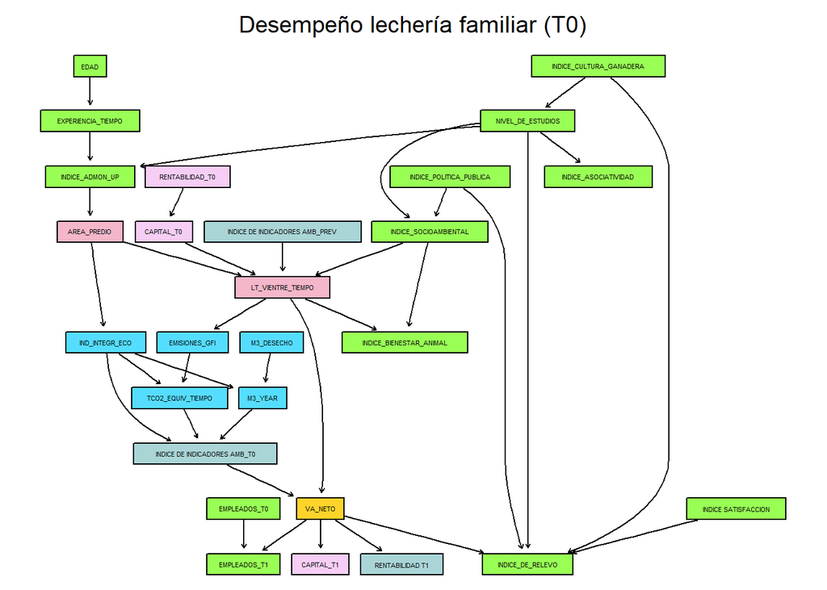

```r
#|label: graf-dag

nodeRenderInfo(leche_gr) <- list(fill = colorear)

renderGraph(leche_gr)
```

```r
as_tibble(sapply(impliedConditionalIndependencies(leche_bn,
                                                  type = "missing.edge"),
                 as.character)) %>%
  datatable()
```

Table 2: Lista de formas de independencia condicional implicadas por el DAG

|  | value |
| --- | --- |
| 1 | AMB_P _\|\|_ AMB_T |
| 2 | AMB_ _\|\|_ AREA |
| 3 | AMB_ _\|\|_ CAPI |
| 4 | AMB_ _\|\|_ CAPI \| VA_N |
| 5 | AMB_ _\|\|_ CAPI \| LT_V |
| 6 | AMB_ _\|\|_ DE |
| 7 | AMB_ _\|\|_ EDAD |
| 8 | AMB_ _\|\|_ EMIS \| LT_V |
| 9 | AMB_ _\|\|_ EMPL |
| 10 | AMB_ _\|\|_ EMPL \| VA_N |

[output cut: 928 more lines]